# Data Preparation

Jongjin Kim

2021 5 28

# Baseline (Week1 - Presented by Isaac Lee)

## Load Libraries (라이브러리 불러오기)

```r
# libraries
library(tidymodels)            # a collection of packages for modeling : load multiple 'tidymodels' packages in a single step
library(tidyverse)             # load multiple 'tidyverse' packages in a single step
library(magrittr)              # includes "pipe" (%>%) operator
library(skimr)                 # includes a function "skim" to skim the dataset
library(knitr)                 # includes a function "purl" to convert RMD to R
library(naniar)                # includes functions to visualize and analyse NAs.
theme_set(theme_bw())          # theme for ggplot2
```

## Load the dataset (데이터셋 불러오기)

```r
# designate the file path. It matches to the kaggle RMD setting.

# file path
# input   /
# ...     / house-prices-advanced-regression-techniques/
# ...     / ... / [train.csv, test.csv, data_description.txt, sample_submission.csv]
# output  /
# yourcode/
# ...     / [data_prep.RMD]

file_path <- "../input/house-prices-advanced-regression-techniques"

# Retrieve the list of files in the path.
files <- list.files(file_path)

# There are four files in the input folder
files
```

```
## [1] "data_description.txt"  "sample_submission.csv" "test.csv"
## [4] "train.csv"
```

```r
# Load the trainset
train <- read_csv(file.path(file_path, "train.csv"))

# Load the testset
test <- read_csv(file.path(file_path, "test.csv"))

# Bind two dataset into "all_data" and clean variable names (turn into lower cases and delim with "_")
all_data <- bind_rows(train, test) %>%
  janitor::clean_names()

all_data %>% head()
```

```
## # A tibble: 6 x 81
##      id ms_sub_class ms_zoning lot_frontage lot_area street alley lot_shape
##   <dbl>        <dbl> <chr>            <dbl>    <dbl> <chr>  <chr> <chr>
## 1     1           60 RL                  65     8450 Pave   NA    Reg
## 2     2           20 RL                  80     9600 Pave   NA    Reg
## 3     3           60 RL                  68    11250 Pave   NA    IR1
## 4     4           70 RL                  60     9550 Pave   NA    IR1
## 5     5           60 RL                  84    14260 Pave   NA    IR1
## 6     6           50 RL                  85    14115 Pave   NA    IR1
## # … with 73 more variables: land_contour <chr>, utilities <chr>,
## #   lot_config <chr>, land_slope <chr>, neighborhood <chr>, condition1 <chr>,
## #   condition2 <chr>, bldg_type <chr>, house_style <chr>, overall_qual <dbl>,
## #   overall_cond <dbl>, year_built <dbl>, year_remod_add <dbl>,
## #   roof_style <chr>, roof_matl <chr>, exterior1st <chr>, exterior2nd <chr>,
## #   mas_vnr_type <chr>, mas_vnr_area <dbl>, exter_qual <chr>, exter_cond <chr>,
## #   foundation <chr>, bsmt_qual <chr>, bsmt_cond <chr>, bsmt_exposure <chr>,
## #   bsmt_fin_type1 <chr>, bsmt_fin_sf1 <dbl>, bsmt_fin_type2 <chr>,
## #   bsmt_fin_sf2 <dbl>, bsmt_unf_sf <dbl>, total_bsmt_sf <dbl>, heating <chr>,
## #   heating_qc <chr>, central_air <chr>, electrical <chr>, x1st_flr_sf <dbl>,
## #   x2nd_flr_sf <dbl>, low_qual_fin_sf <dbl>, gr_liv_area <dbl>,
## #   bsmt_full_bath <dbl>, bsmt_half_bath <dbl>, full_bath <dbl>,
## #   half_bath <dbl>, bedroom_abv_gr <dbl>, kitchen_abv_gr <dbl>,
## #   kitchen_qual <chr>, tot_rms_abv_grd <dbl>, functional <chr>,
## #   fireplaces <dbl>, fireplace_qu <chr>, garage_type <chr>,
## #   garage_yr_blt <dbl>, garage_finish <chr>, garage_cars <dbl>,
## #   garage_area <dbl>, garage_qual <chr>, garage_cond <chr>, paved_drive <chr>,
## #   wood_deck_sf <dbl>, open_porch_sf <dbl>, enclosed_porch <dbl>,
## #   x3ssn_porch <dbl>, screen_porch <dbl>, pool_area <dbl>, pool_qc <chr>,
## #   fence <chr>, misc_feature <chr>, misc_val <dbl>, mo_sold <dbl>,
## #   yr_sold <dbl>, sale_type <chr>, sale_condition <chr>, sale_price <dbl>
```

## Recipe 1 (Baseline with Lasso Model)

1. Set Target Variable as sale_price
2. Remove id
3. Log Transformation for sale_price (because it is right-skewed)
4. Impute NAs with mode for all nominal variables (categorical variable)
5. Create a dummy variable for all nominal variables (81 -> 246 variables)
6. Impute NAs with mean for all other predictors (numerical variables)
7. Normalize all predictors
8. Prep.

```r
# Recipe for the tidymodels
housing_recipe1 <- all_data %>%
    recipe(sale_price ~ .) %>%
    step_rm(id) %>%
    step_log(sale_price) %>%
    step_impute_mode(all_nominal()) %>%
    step_dummy(all_nominal()) %>%
    step_impute_mean(all_predictors()) %>%
    step_normalize(all_predictors()) %>%
    prep()

print(housing_recipe1)
```

```
## Data Recipe
##
## Inputs:
##
##       role #variables
##    outcome          1
##  predictor         80
##
## Training data contained 2919 data points and 2919 incomplete rows.
##
## Operations:
##
## Variables removed id [trained]
## Log transformation on sale_price [trained]
## Mode Imputation for ms_zoning, street, alley, ... [trained]
## Dummy variables from ms_zoning, street, alley, lot_shape, ... [trained]
## Mean Imputation for ms_sub_class, lot_frontage, ... [trained]
## Centering and scaling for ms_sub_class, lot_frontage, ... [trained]
```

```r
# Preprocess the recipe1
all_data1 <- recipes::juice(housing_recipe1)
```

```r
# Get the index for trainset
train_index <- seq_len(nrow(train))

# Get the pre-processed trainset
train1 <- all_data1[train_index,]

# Get the pre-processed testset
test1 <- all_data1[-train_index,]
```

```r
# Lasso model using glmnet engine with penalty 0.01 and mixture 1
lasso_model1 <-
  linear_reg(penalty = 0.01, mixture = 1) %>%
  set_engine("glmnet")

# Run the model with formula sale_price ~ .(all other predictors) with dataset train1.
lasso_fit1 <-
  lasso_model1 %>%
  fit(sale_price ~ ., data = train1)

# Find the estimates that are higher than 0.001.
lasso_fit1 %>%
  tidy() %>%
  filter(abs(estimate) > 0.001) %>%
  arrange(estimate %>% abs %>% desc)
```

```
## # A tibble: 50 x 3
##    term               estimate penalty
##    <chr>                 <dbl>   <dbl>
##  1 (Intercept)         12.0       0.01
##  2 overall_qual         0.115     0.01
##  3 gr_liv_area          0.105     0.01
##  4 garage_cars          0.0487    0.01
##  5 year_built           0.0396    0.01
##  6 overall_cond         0.0306    0.01
##  7 year_remod_add       0.0216    0.01
##  8 total_bsmt_sf        0.0202    0.01
##  9 fireplaces           0.0201    0.01
## 10 bsmt_fin_type1_Unf  -0.0179    0.01
## # … with 40 more rows
```

```r
# Get the predicted values from the lasso model 1
result1 <- predict(lasso_fit1, test1)
result1 %>% head()
```

```
## # A tibble: 6 x 1
##   .pred
##   <dbl>
## 1  11.6
## 2  11.9
## 3  12.0
## 4  12.2
## 5  12.2
## 6  12.1
```

```r
# Load the submission file
submission <- read_csv(file.path(file_path, "sample_submission.csv"))

# Exponential the sale_price because it is log transformed in preprocessing.
submission$SalePrice <- exp(result1$.pred)

# Write the submission file
write.csv(submission, row.names = FALSE,
          "../output/lasso_regression_0point1.csv")
```

0.14193 (rank 5433)

# Predictors used in the lasso model?

현재 LASSO 모델에서 영향을 크게 미치는 변수들을 찾아봤습니다. MS_SUB_CLASS 의 경우 범주형으로 보였는데, 모델에서는 Numeric으로 들어가 있는 상태이지만, 유의미한 estimate이 나오는 걸로 나오는게 신기하네요. NA의 비율이 많았던 범주형 변수들의 경우 LASSO 모델에서는 제외가 되었네요.

```r
# Get the variables which have high estimates in the LASSO model
vars <- lasso_fit1 %>%
  tidy() %>%
  filter(abs(estimate) > 0.001) %>%
  dplyr::arrange(estimate %>% abs %>% desc)

# Variables that have high estimate values
vars[1:10,]
```

```
## # A tibble: 10 x 3
##    term               estimate penalty
##    <chr>                 <dbl>   <dbl>
##  1 (Intercept)         12.0       0.01
##  2 overall_qual         0.115     0.01
##  3 gr_liv_area          0.105     0.01
##  4 garage_cars          0.0487    0.01
##  5 year_built           0.0396    0.01
##  6 overall_cond         0.0306    0.01
##  7 year_remod_add       0.0216    0.01
##  8 total_bsmt_sf        0.0202    0.01
##  9 fireplaces           0.0201    0.01
## 10 bsmt_fin_type1_Unf  -0.0179    0.01
```

```r
vars[11:20,]
```

```
## # A tibble: 10 x 3
##    term                 estimate penalty
##    <chr>                   <dbl>   <dbl>
##  1 bsmt_full_bath        0.0175     0.01
##  2 central_air_Y         0.0168     0.01
##  3 neighborhood_NridgHt  0.0157     0.01
##  4 ms_zoning_RM         -0.0153     0.01
##  5 neighborhood_Crawfor  0.0139     0.01
##  6 condition2_PosN      -0.0138     0.01
##  7 ms_sub_class         -0.0123     0.01
##  8 foundation_PConc      0.0112     0.01
##  9 garage_finish_Unf    -0.0103     0.01
## 10 bsmt_exposure_Gd      0.00996    0.01
```

```r
vars[21:30,]
```

```
## # A tibble: 10 x 3
##    term                 estimate penalty
##    <chr>                   <dbl>   <dbl>
##  1 condition1_Norm       0.00970    0.01
##  2 sale_type_New         0.00905    0.01
##  3 lot_area              0.00901    0.01
##  4 ms_zoning_RL          0.00880    0.01
##  5 wood_deck_sf          0.00863    0.01
##  6 screen_porch          0.00746    0.01
##  7 neighborhood_Edwards -0.00721    0.01
##  8 bldg_type_Twnhs      -0.00665    0.01
##  9 neighborhood_StoneBr  0.00664    0.01
## 10 full_bath             0.00644    0.01
```

```r
vars[31:40,]
```

```
## # A tibble: 10 x 3
##    term                 estimate penalty
##    <chr>                   <dbl>   <dbl>
##  1 tot_rms_abv_grd       0.00626    0.01
##  2 functional_Maj2      -0.00526    0.01
##  3 neighborhood_IDOTRR  -0.00514    0.01
##  4 lot_config_CulDSac    0.00491    0.01
##  5 garage_area           0.00490    0.01
##  6 heating_qc_TA        -0.00472    0.01
##  7 kitchen_qual_TA      -0.00463    0.01
##  8 neighborhood_Somerst  0.00436    0.01
##  9 exterior1st_BrkFace   0.00421    0.01
## 10 functional_Typ        0.00391    0.01
```

```r
vars[41:50,]
```

```
## # A tibble: 10 x 3
##    term                 estimate penalty
##    <chr>                   <dbl>   <dbl>
##  1 bsmt_exposure_No     -0.00368    0.01
##  2 lot_shape_IR3        -0.00249    0.01
##  3 x1st_flr_sf           0.00233    0.01
##  4 neighborhood_NoRidge  0.00219    0.01
##  5 exter_qual_TA        -0.00147    0.01
##  6 paved_drive_Y         0.00141    0.01
##  7 neighborhood_ClearCr  0.00134    0.01
##  8 heating_Grav         -0.00108    0.01
##  9 bsmt_fin_type1_GLQ    0.00103    0.01
## 10 exter_cond_Fa        -0.00101    0.01
```

```r
# NA dominants variables (pool_qc, fence, misc_feature, alley, fireplace_qu)

lasso_fit1 %>%
  tidy() %>%
  filter(stringr::str_starts(term, "pool_qc"))
```

```
## # A tibble: 2 x 3
##   term       estimate penalty
##   <chr>         <dbl>   <dbl>
## 1 pool_qc_Fa        0    0.01
## 2 pool_qc_Gd        0    0.01
```

```r
lasso_fit1 %>%
  tidy() %>%
  filter(stringr::str_starts(term, "fence"))
```

```
## # A tibble: 3 x 3
##   term        estimate penalty
##   <chr>          <dbl>   <dbl>
## 1 fence_GdWo         0    0.01
## 2 fence_MnPrv        0    0.01
## 3 fence_MnWw         0    0.01
```

```r
lasso_fit1 %>%
  tidy() %>%
  filter(stringr::str_starts(term, "misc_feature"))
```

```
## # A tibble: 3 x 3
##   term              estimate penalty
##   <chr>                <dbl>   <dbl>
## 1 misc_feature_Othr        0    0.01
## 2 misc_feature_Shed        0    0.01
## 3 misc_feature_TenC        0    0.01
```

```r
lasso_fit1 %>%
  tidy() %>%
  filter(stringr::str_starts(term, "alley"))
```

```
## # A tibble: 1 x 3
##   term       estimate penalty
##   <chr>         <dbl>   <dbl>
## 1 alley_Pave        0    0.01
```

```r
lasso_fit1 %>%
  tidy() %>%
  filter(stringr::str_starts(term, "fireplace_qu"))
```

```
## # A tibble: 4 x 3
##   term            estimate penalty
##   <chr>              <dbl>   <dbl>
## 1 fireplace_qu_Fa        0    0.01
## 2 fireplace_qu_Gd        0    0.01
## 3 fireplace_qu_Po        0    0.01
## 4 fireplace_qu_TA        0    0.01
```

# Preprocessing (전처리)

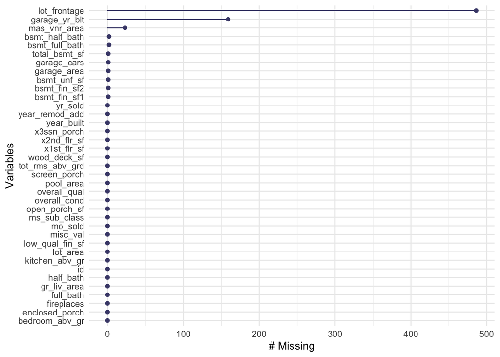

```r
library(caret)

# Select numeric data
all_data_numeric <- all_data %>%
  select_if(is.numeric) %>%
  select(-"sale_price")

# Select categorical data
all_data_character <- all_data %>% select_if(is.character)

# Find the missing value distribution
all_data_numeric %>% naniar::gg_miss_var()
```

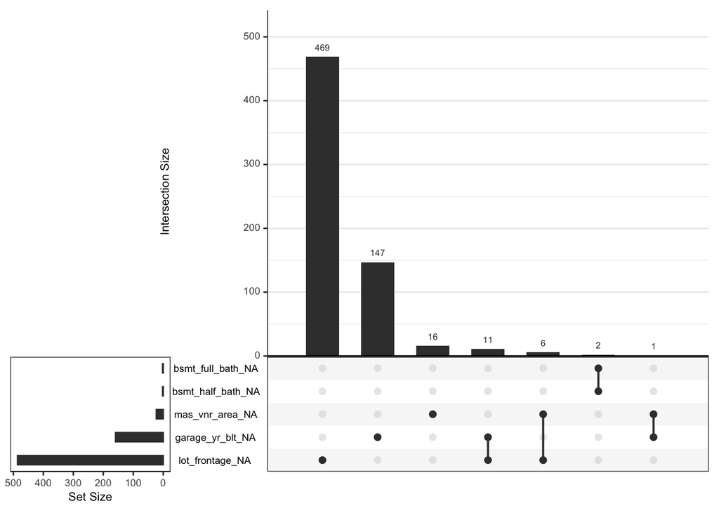

```r
# Find the missing value distribution
all_data_numeric %>% naniar::gg_miss_upset()
```

```r
# lot_frontage : Linear feet of street connected to property
# garage_yr_blt : the year when garage was built.

# Get the data where there is a missing value in lot_frontage
all_data_numeric %>% filter(is.na(lot_frontage))
```

```
## # A tibble: 486 x 37
##       id ms_sub_class lot_frontage lot_area overall_qual overall_cond year_built
##    <dbl>        <dbl>        <dbl>    <dbl>        <dbl>        <dbl>      <dbl>
##  1     8           60           NA    10382            7            6       1973
##  2    13           20           NA    12968            5            6       1962
##  3    15           20           NA    10920            6            5       1960
##  4    17           20           NA    11241            6            7       1970
##  5    25           20           NA     8246            5            8       1968
##  6    32           20           NA     8544            5            6       1966
##  7    43           85           NA     9180            5            7       1983
##  8    44           20           NA     9200            5            6       1975
##  9    51           60           NA    13869            6            6       1997
## 10    65           60           NA     9375            7            5       1997
## # … with 476 more rows, and 30 more variables: year_remod_add <dbl>,
## #   mas_vnr_area <dbl>, bsmt_fin_sf1 <dbl>, bsmt_fin_sf2 <dbl>,
## #   bsmt_unf_sf <dbl>, total_bsmt_sf <dbl>, x1st_flr_sf <dbl>,
## #   x2nd_flr_sf <dbl>, low_qual_fin_sf <dbl>, gr_liv_area <dbl>,
## #   bsmt_full_bath <dbl>, bsmt_half_bath <dbl>, full_bath <dbl>,
## #   half_bath <dbl>, bedroom_abv_gr <dbl>, kitchen_abv_gr <dbl>,
## #   tot_rms_abv_grd <dbl>, fireplaces <dbl>, garage_yr_blt <dbl>,
## #   garage_cars <dbl>, garage_area <dbl>, wood_deck_sf <dbl>,
## #   open_porch_sf <dbl>, enclosed_porch <dbl>, x3ssn_porch <dbl>,
## #   screen_porch <dbl>, pool_area <dbl>, misc_val <dbl>, mo_sold <dbl>,
## #   yr_sold <dbl>
```

```r
# Get the data where there is a missing value in garage_yr_blt
all_data_numeric %>% filter(is.na(garage_yr_blt)) %>% .$garage_area
```

```
##   [1]   0   0   0   0   0   0   0   0   0   0   0   0   0   0   0   0   0   0
##  [19]   0   0   0   0   0   0   0   0   0   0   0   0   0   0   0   0   0   0
##  [37]   0   0   0   0   0   0   0   0   0   0   0   0   0   0   0   0   0   0
##  [55]   0   0   0   0   0   0   0   0   0   0   0   0   0   0   0   0   0   0
##  [73]   0   0   0   0   0   0   0   0   0   0   0   0   0   0   0   0   0   0
##  [91]   0   0   0   0   0   0   0   0   0   0   0   0   0   0   0   0   0   0
## [109]   0   0   0   0   0   0 360   0   0   0   0   0   0   0   0   0   0   0
## [127]   0   0   0   0   0   0   0   0   0   0  NA   0   0   0   0   0   0   0
## [145]   0   0   0   0   0   0   0   0   0   0   0   0   0   0   0
```

```r
all_data_numeric %>% filter(is.na(garage_yr_blt)) %>% .$garage_area %>% length()
```

```
## [1] 159
```

```r
# Find the cases where year_built == garage_yr_blt
all_data_numeric %>%
  mutate(isGarageBuilt = case_when(garage_yr_blt == year_built ~ TRUE, TRUE ~ FALSE)) %>%
  .$isGarageBuilt %>%
  sum(na.rm = TRUE)
```

```
## [1] 2216
```

```r
# Add the cases where year_remod_add == garage_yr_blt
all_data_numeric %>%
  mutate(isGarageBuilt = case_when(garage_yr_blt == year_built ~ TRUE,
                                   garage_yr_blt == year_remod_add ~ TRUE,
                                   TRUE ~ FALSE)) %>%
  .$isGarageBuilt %>%
  sum(na.rm = TRUE)
```

```
## [1] 2313
```

```r
# No patterns in year_built
all_data_numeric %>%
  filter(garage_yr_blt != year_built) %>%
  filter(garage_yr_blt != year_remod_add) %>%
  select(garage_yr_blt, year_built, year_remod_add)
```

```
## # A tibble: 447 x 3
##    garage_yr_blt year_built year_remod_add
##            <dbl>      <dbl>          <dbl>
##  1          1998       1915           1970
##  2          1991       1929           2001
##  3          2005       1951           2000
##  4          1920       1927           1950
##  5          1977       1975           1980
##  6          1985       1934           1950
##  7          1962       1955           1955
##  8          1973       1972           1972
##  9          2006       2004           2004
## 10          1935       1920           1996
## # … with 437 more rows
```

```r
all_data_numeric %>% filter(is.na(garage_yr_blt)) %>% filter(garage_area != 0)
```

```
## # A tibble: 1 x 37
##      id ms_sub_class lot_frontage lot_area overall_qual overall_cond year_built
##   <dbl>        <dbl>        <dbl>    <dbl>        <dbl>        <dbl>      <dbl>
## 1  2127           60           57     8094            6            8       1910
## # … with 30 more variables: year_remod_add <dbl>, mas_vnr_area <dbl>,
## #   bsmt_fin_sf1 <dbl>, bsmt_fin_sf2 <dbl>, bsmt_unf_sf <dbl>,
## #   total_bsmt_sf <dbl>, x1st_flr_sf <dbl>, x2nd_flr_sf <dbl>,
## #   low_qual_fin_sf <dbl>, gr_liv_area <dbl>, bsmt_full_bath <dbl>,
## #   bsmt_half_bath <dbl>, full_bath <dbl>, half_bath <dbl>,
## #   bedroom_abv_gr <dbl>, kitchen_abv_gr <dbl>, tot_rms_abv_grd <dbl>,
## #   fireplaces <dbl>, garage_yr_blt <dbl>, garage_cars <dbl>,
## #   garage_area <dbl>, wood_deck_sf <dbl>, open_porch_sf <dbl>,
## #   enclosed_porch <dbl>, x3ssn_porch <dbl>, screen_porch <dbl>,
## #   pool_area <dbl>, misc_val <dbl>, mo_sold <dbl>, yr_sold <dbl>
```

```r
all_data$garage_yr_blt[2127] <- all_data$year_built[2127]
```

## Box Cox Transformation

현재 베이스라인에서는 타겟 변수인 Sale_Price에 대해서는 Log Transformation을 진행하여 Normality를 띠도록 만들었지만, 그 외의 Predictor들도 Normality를 띠도록 변경해줄 필요가 있습니다. 이를 위해 caret 패키지의 preProcess 함수를 사용하여 BoxCox Transformation을 진행하려고 합니다. BoxCox Transformation은 정규성을 띠지 않는 변수를 power transformation을 통하여 정규성을 띠도록 변경하는 과정인데요. 링크 : [BoxCox Transformation](https://www.statisticshowto.com/box-cox-transformation/) 이 과정에서 lambda라는 값이 주어지며, 간단하게는 lambda 값이 0이면, log transformation, lambda 값이 2이면 제곱, lambda 값이 0.5 이면 루트를 씌운다고 생각하면 됩니다.

```r
# Apply mean imputation
all_data_numeric_meanimpute <- sapply(X = all_data_numeric,
                                      FUN = impute_mean)

# There is no negative data
any(all_data_numeric_meanimpute < 0)
```

```
## [1] FALSE
```

```r
# summary of numeric data
summary(all_data_numeric)
```

```
##        id          ms_sub_class     lot_frontage       lot_area
##  Min.   :   1.0   Min.   : 20.00   Min.   : 21.00   Min.   :  1300
##  1st Qu.: 730.5   1st Qu.: 20.00   1st Qu.: 59.00   1st Qu.:  7478
##  Median :1460.0   Median : 50.00   Median : 68.00   Median :  9453
##  Mean   :1460.0   Mean   : 57.14   Mean   : 69.31   Mean   : 10168
##  3rd Qu.:2189.5   3rd Qu.: 70.00   3rd Qu.: 80.00   3rd Qu.: 11570
##  Max.   :2919.0   Max.   :190.00   Max.   :313.00   Max.   :215245
##                                    NA's   :486
##   overall_qual     overall_cond     year_built   year_remod_add
##  Min.   : 1.000   Min.   :1.000   Min.   :1872   Min.   :1950
##  1st Qu.: 5.000   1st Qu.:5.000   1st Qu.:1954   1st Qu.:1965
##  Median : 6.000   Median :5.000   Median :1973   Median :1993
##  Mean   : 6.089   Mean   :5.565   Mean   :1971   Mean   :1984
##  3rd Qu.: 7.000   3rd Qu.:6.000   3rd Qu.:2001   3rd Qu.:2004
##  Max.   :10.000   Max.   :9.000   Max.   :2010   Max.   :2010
##
##   mas_vnr_area     bsmt_fin_sf1     bsmt_fin_sf2      bsmt_unf_sf
##  Min.   :   0.0   Min.   :   0.0   Min.   :   0.00   Min.   :   0.0
##  1st Qu.:   0.0   1st Qu.:   0.0   1st Qu.:   0.00   1st Qu.: 220.0
##  Median :   0.0   Median : 368.5   Median :   0.00   Median : 467.0
##  Mean   : 102.2   Mean   : 441.4   Mean   :  49.58   Mean   : 560.8
##  3rd Qu.: 164.0   3rd Qu.: 733.0   3rd Qu.:   0.00   3rd Qu.: 805.5
##  Max.   :1600.0   Max.   :5644.0   Max.   :1526.00   Max.   :2336.0
##  NA's   :23       NA's   :1        NA's   :1         NA's   :1
##  total_bsmt_sf     x1st_flr_sf    x2nd_flr_sf     low_qual_fin_sf
##  Min.   :   0.0   Min.   : 334   Min.   :   0.0   Min.   :   0.000
##  1st Qu.: 793.0   1st Qu.: 876   1st Qu.:   0.0   1st Qu.:   0.000
##  Median : 989.5   Median :1082   Median :   0.0   Median :   0.000
##  Mean   :1051.8   Mean   :1160   Mean   : 336.5   Mean   :   4.694
##  3rd Qu.:1302.0   3rd Qu.:1388   3rd Qu.: 704.0   3rd Qu.:   0.000
##  Max.   :6110.0   Max.   :5095   Max.   :2065.0   Max.   :1064.000
##  NA's   :1
##   gr_liv_area   bsmt_full_bath   bsmt_half_bath      full_bath
##  Min.   : 334   Min.   :0.0000   Min.   :0.00000   Min.   :0.000
##  1st Qu.:1126   1st Qu.:0.0000   1st Qu.:0.00000   1st Qu.:1.000
##  Median :1444   Median :0.0000   Median :0.00000   Median :2.000
##  Mean   :1501   Mean   :0.4299   Mean   :0.06136   Mean   :1.568
##  3rd Qu.:1744   3rd Qu.:1.0000   3rd Qu.:0.00000   3rd Qu.:2.000
##  Max.   :5642   Max.   :3.0000   Max.   :2.00000   Max.   :4.000
##                 NA's   :2        NA's   :2
```

[output cut: 25 more lines]

```
##  Min.   :  0.00   Min.   :  0.000   Min.   :    0.00   Min.   : 1.000
##  1st Qu.:  0.00   1st Qu.:  0.000   1st Qu.:    0.00   1st Qu.: 4.000
##  Median :  0.00   Median :  0.000   Median :    0.00   Median : 6.000
##  Mean   : 16.06   Mean   :  2.252   Mean   :   50.83   Mean   : 6.213
##  3rd Qu.:  0.00   3rd Qu.:  0.000   3rd Qu.:    0.00   3rd Qu.: 8.000
##  Max.   :576.00   Max.   :800.000   Max.   :17000.00   Max.   :12.000
##
##     yr_sold
##  Min.   :2006
##  1st Qu.:2007
##  Median :2008
##  Mean   :2008
##  3rd Qu.:2009
##  Max.   :2010
##
```

```r
# Run the preprocess function
BoxCox <- caret::preProcess(x = all_data_numeric_meanimpute,
                            method = c("BoxCox", "center", "scale"))

# See the overall result of preprocess
BoxCox
```

```
## Created from 2919 samples and 37 variables
##
## Pre-processing:
##   - Box-Cox transformation (14)
##   - centered (37)
##   - ignored (0)
##   - scaled (37)
##
## Lambda estimates for Box-Cox transformation:
##    Min. 1st Qu.  Median    Mean 3rd Qu.    Max.
## -2.0000  0.0250  0.6000  0.5286  0.8000  2.0000
```

```r
# See the variables that needed to be transformed
BoxCox$method
```

```
## $BoxCox
##  [1] "id"              "ms_sub_class"    "lot_frontage"    "lot_area"
##  [5] "overall_qual"    "overall_cond"    "year_built"      "year_remod_add"
##  [9] "x1st_flr_sf"     "gr_liv_area"     "tot_rms_abv_grd" "garage_yr_blt"
## [13] "mo_sold"         "yr_sold"
##
## $center
##  [1] "id"              "ms_sub_class"    "lot_frontage"    "lot_area"
##  [5] "overall_qual"    "overall_cond"    "year_built"      "year_remod_add"
##  [9] "mas_vnr_area"    "bsmt_fin_sf1"    "bsmt_fin_sf2"    "bsmt_unf_sf"
## [13] "total_bsmt_sf"   "x1st_flr_sf"     "x2nd_flr_sf"     "low_qual_fin_sf"
## [17] "gr_liv_area"     "bsmt_full_bath"  "bsmt_half_bath"  "full_bath"
## [21] "half_bath"       "bedroom_abv_gr"  "kitchen_abv_gr"  "tot_rms_abv_grd"
## [25] "fireplaces"      "garage_yr_blt"   "garage_cars"     "garage_area"
## [29] "wood_deck_sf"    "open_porch_sf"   "enclosed_porch"  "x3ssn_porch"
```

[output cut: 17 more lines]

```r
# See the details of the BoxCox transformation
BoxCox$bc
```

```
## $id
## Box-Cox Transformation
##
## 2919 data points used to estimate Lambda
##
## Input data summary:
##    Min. 1st Qu.  Median    Mean 3rd Qu.    Max.
##     1.0   730.5  1460.0  1460.0  2189.5  2919.0
##
## Largest/Smallest: 2920
## Sample Skewness: 0
##
## Estimated Lambda: 0.7
##
##
## $ms_sub_class
## Box-Cox Transformation
##
## 2919 data points used to estimate Lambda
##
## Input data summary:
##    Min. 1st Qu.  Median    Mean 3rd Qu.    Max.
##   20.00   20.00   50.00   57.14   70.00  190.00
##
## Largest/Smallest: 9.5
## Sample Skewness: 1.37
##
## Estimated Lambda: -0.2
## With fudge factor, Lambda = 0 will be used for transformations
##
##
## $lot_frontage
## Box-Cox Transformation
##
## 2919 data points used to estimate Lambda
##
## Input data summary:
##    Min. 1st Qu.  Median    Mean 3rd Qu.    Max.
##   21.00   60.00   69.31   69.31   78.00  313.00
##
```

[output cut: 160 more lines]

```
##
##
## $yr_sold
## Box-Cox Transformation
##
## 2919 data points used to estimate Lambda
##
## Input data summary:
##    Min. 1st Qu.  Median    Mean 3rd Qu.    Max.
##    2006    2007    2008    2008    2009    2010
##
## Largest/Smallest: 1
## Sample Skewness: 0.132
##
## Estimated Lambda: -2
```

```r
# Unlist the boxcox results
bc <- BoxCox$bc %>% unlist()

# get index that have the name ending with lambda
idx <- names(bc) %>% stringr::str_ends("lambda")

# get the lambda result
bc[idx]
```

```
##              id.lambda    ms_sub_class.lambda    lot_frontage.lambda
##                    0.7                   -0.2                    0.5
##        lot_area.lambda    overall_qual.lambda    overall_cond.lambda
##                    0.1                    0.8                    0.7
##      year_built.lambda  year_remod_add.lambda     x1st_flr_sf.lambda
##                    2.0                    2.0                   -0.1
##     gr_liv_area.lambda tot_rms_abv_grd.lambda   garage_yr_blt.lambda
##                    0.0                    0.1                    2.0
##         mo_sold.lambda         yr_sold.lambda
##                    0.8                   -2.0
```

```r
# it is close to 0 -> log transformation
# it is close to 0.5 -> square root transformation
# it is close to 2 -> square transformation

# lot_area, x1st_flr_sf, gr_liv_area, tot_rms_abv_grd -> log transformation
# lot_frontage -> square root transformation
# garage_yr_blt, year_built -> square transformation
```

## Visualization of the variables that are needed to be transformed

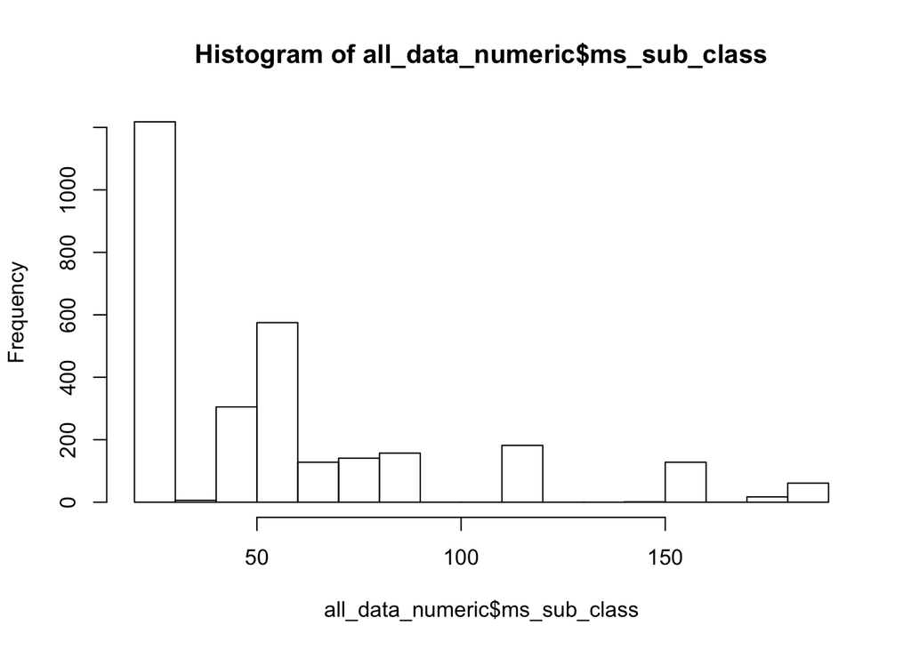

```r
# This is a categorical (not ordinal)
hist(all_data_numeric$ms_sub_class)  # Categorical
```

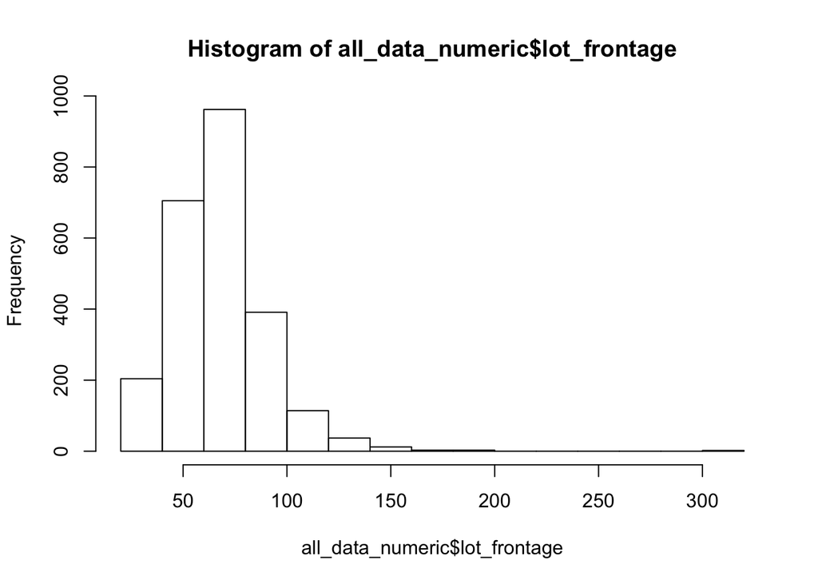

```r
# Histogram of lot_frontage
hist(all_data_numeric$lot_frontage)  # Square root Transformation needed
```

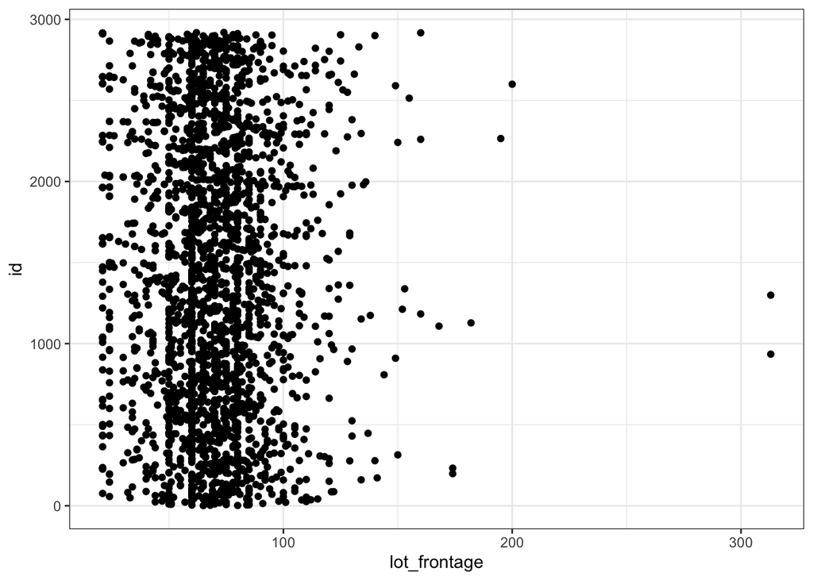

```r
ggplot(all_data_numeric, aes(x = lot_frontage, y = id)) +
  geom_point()
```

```r
all_data_numeric %>% filter(lot_frontage > 300)
```

```
## # A tibble: 2 x 37
##      id ms_sub_class lot_frontage lot_area overall_qual overall_cond year_built
##   <dbl>        <dbl>        <dbl>    <dbl>        <dbl>        <dbl>      <dbl>
## 1   935           20          313    27650            7            7       1960
## 2  1299           60          313    63887           10            5       2008
## # … with 30 more variables: year_remod_add <dbl>, mas_vnr_area <dbl>,
## #   bsmt_fin_sf1 <dbl>, bsmt_fin_sf2 <dbl>, bsmt_unf_sf <dbl>,
## #   total_bsmt_sf <dbl>, x1st_flr_sf <dbl>, x2nd_flr_sf <dbl>,
## #   low_qual_fin_sf <dbl>, gr_liv_area <dbl>, bsmt_full_bath <dbl>,
## #   bsmt_half_bath <dbl>, full_bath <dbl>, half_bath <dbl>,
## #   bedroom_abv_gr <dbl>, kitchen_abv_gr <dbl>, tot_rms_abv_grd <dbl>,
## #   fireplaces <dbl>, garage_yr_blt <dbl>, garage_cars <dbl>,
## #   garage_area <dbl>, wood_deck_sf <dbl>, open_porch_sf <dbl>,
## #   enclosed_porch <dbl>, x3ssn_porch <dbl>, screen_porch <dbl>,
## #   pool_area <dbl>, misc_val <dbl>, mo_sold <dbl>, yr_sold <dbl>
```

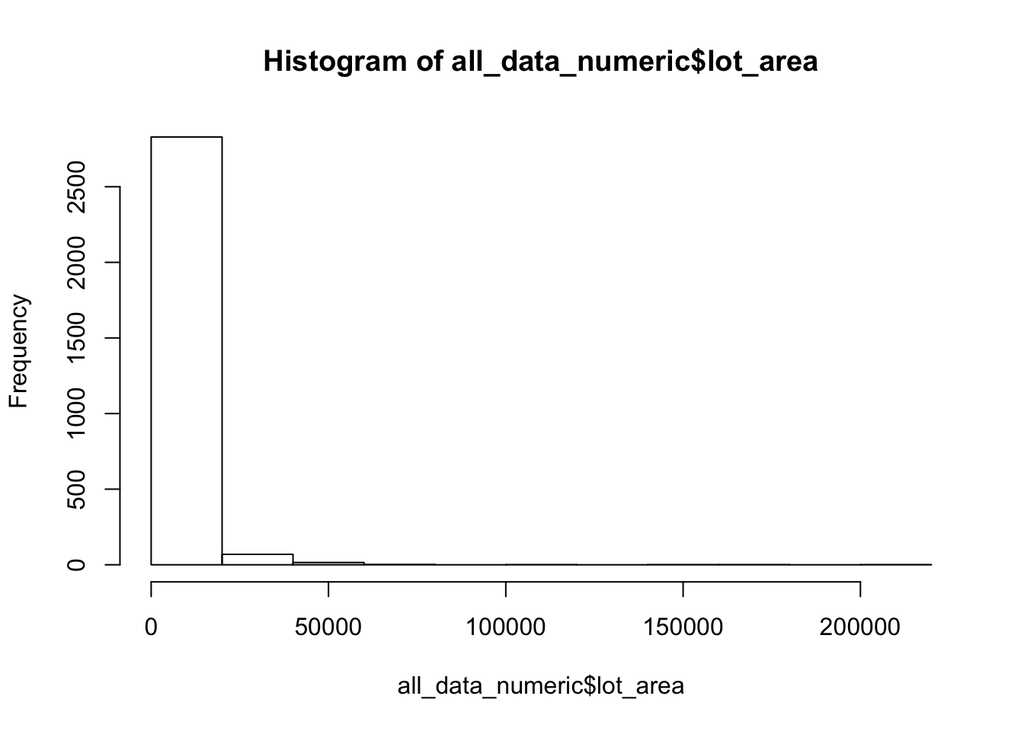

```r
# Histogram of lot_area
hist(all_data_numeric$lot_area)      # Log-Transform needed
```

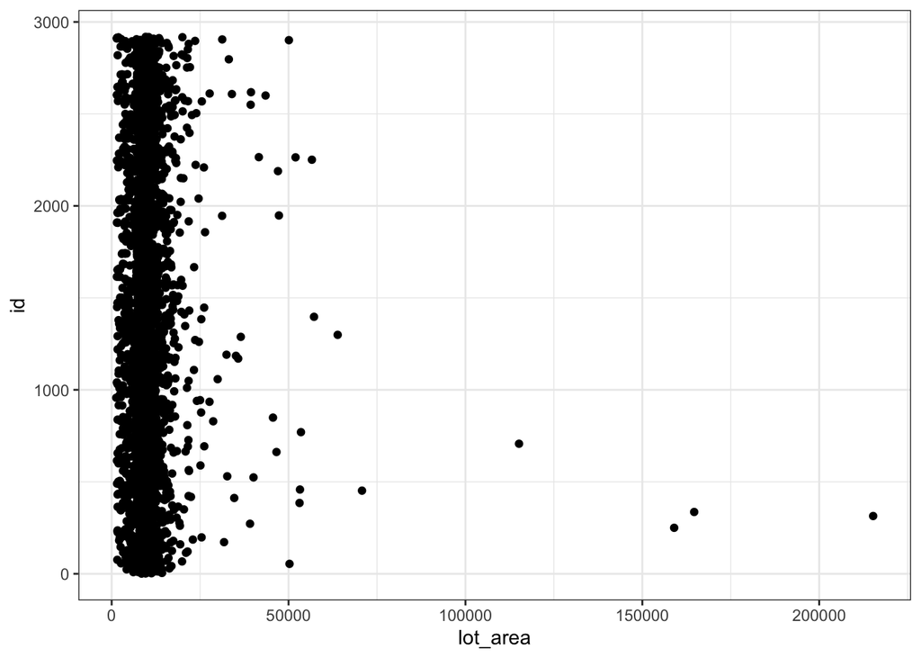

```r
ggplot(all_data_numeric, aes(x = lot_area, y = id)) +
  geom_point()
```

```r
all_data_numeric %>% filter(lot_area > 100000)
```

```
## # A tibble: 4 x 37
##      id ms_sub_class lot_frontage lot_area overall_qual overall_cond year_built
##   <dbl>        <dbl>        <dbl>    <dbl>        <dbl>        <dbl>      <dbl>
## 1   250           50           NA   159000            6            7       1958
## 2   314           20          150   215245            7            5       1965
## 3   336          190           NA   164660            5            6       1965
## 4   707           20           NA   115149            7            5       1971
## # … with 30 more variables: year_remod_add <dbl>, mas_vnr_area <dbl>,
## #   bsmt_fin_sf1 <dbl>, bsmt_fin_sf2 <dbl>, bsmt_unf_sf <dbl>,
## #   total_bsmt_sf <dbl>, x1st_flr_sf <dbl>, x2nd_flr_sf <dbl>,
## #   low_qual_fin_sf <dbl>, gr_liv_area <dbl>, bsmt_full_bath <dbl>,
## #   bsmt_half_bath <dbl>, full_bath <dbl>, half_bath <dbl>,
## #   bedroom_abv_gr <dbl>, kitchen_abv_gr <dbl>, tot_rms_abv_grd <dbl>,
## #   fireplaces <dbl>, garage_yr_blt <dbl>, garage_cars <dbl>,
## #   garage_area <dbl>, wood_deck_sf <dbl>, open_porch_sf <dbl>,
## #   enclosed_porch <dbl>, x3ssn_porch <dbl>, screen_porch <dbl>,
## #   pool_area <dbl>, misc_val <dbl>, mo_sold <dbl>, yr_sold <dbl>
```

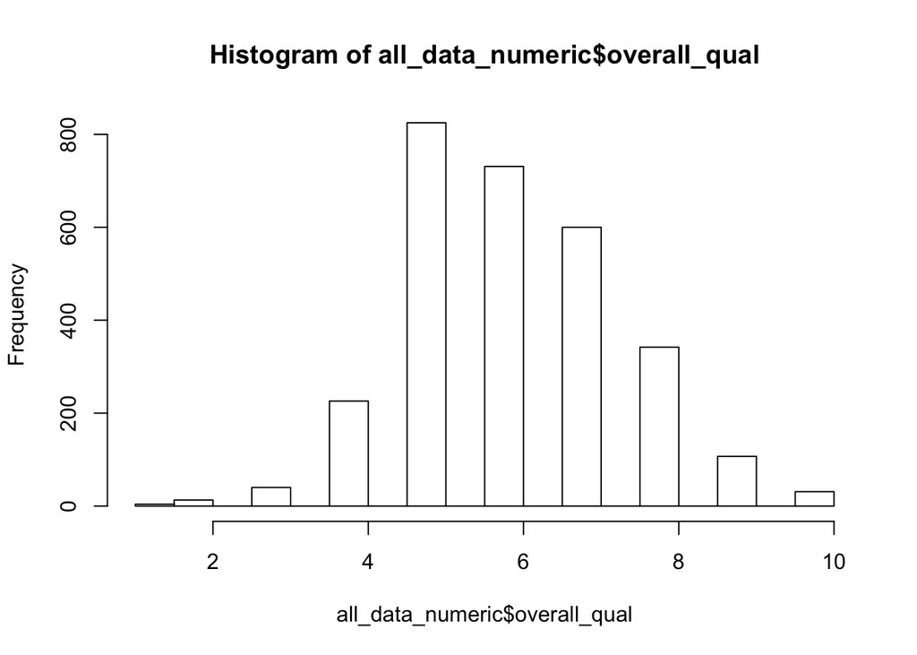

```r
# Histogram of overall_qual
hist(all_data_numeric$overall_qual)  # No transform
```

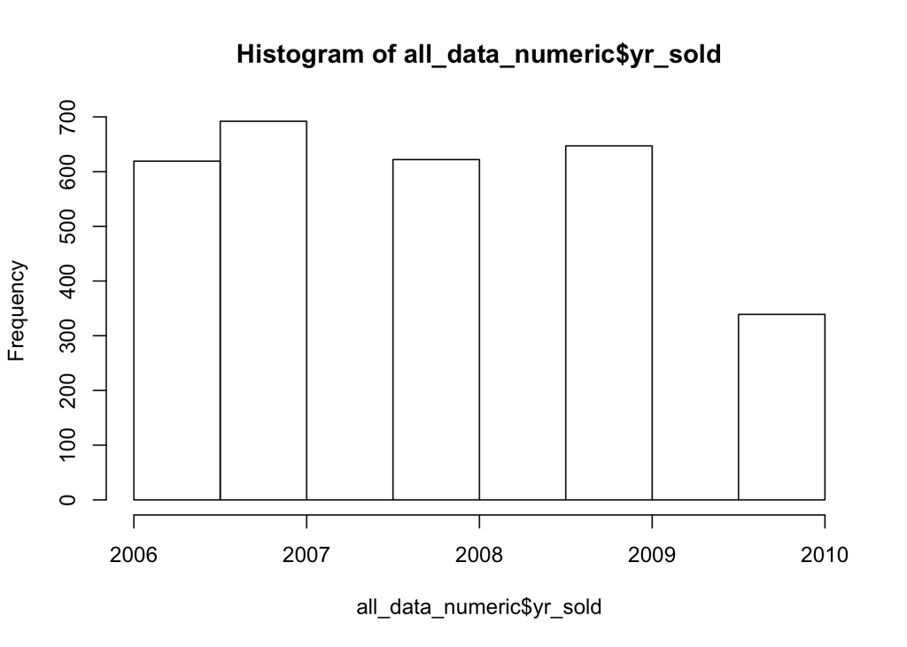

```r
# Histogram of yr_sold
hist(all_data_numeric$yr_sold)       # No transform
```

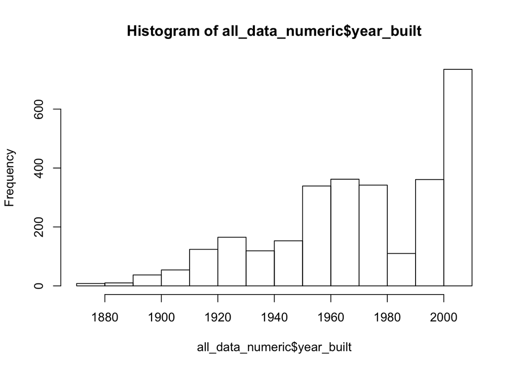

```r
# Histogram of year_built
hist(all_data_numeric$year_built)    # Square Transform
```

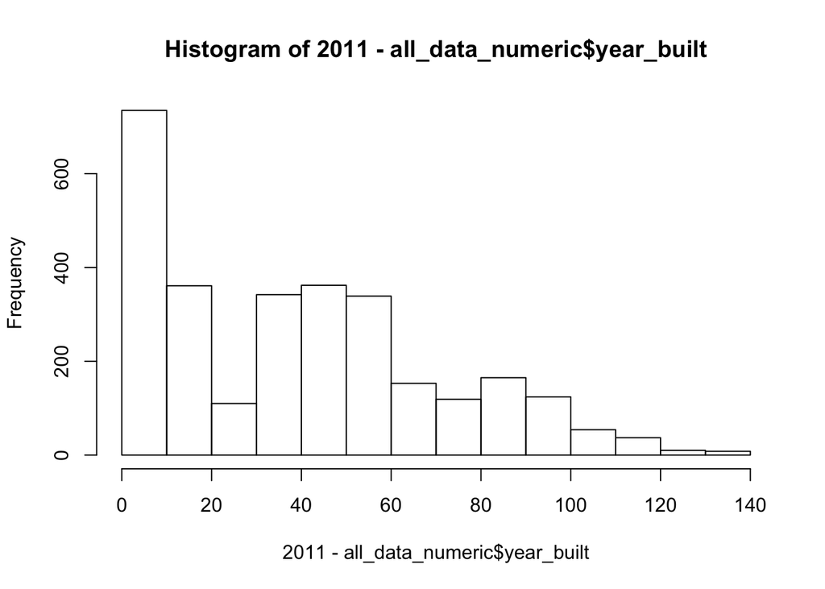

```r
hist(2011 - all_data_numeric$year_built)    # Log-Transform
```

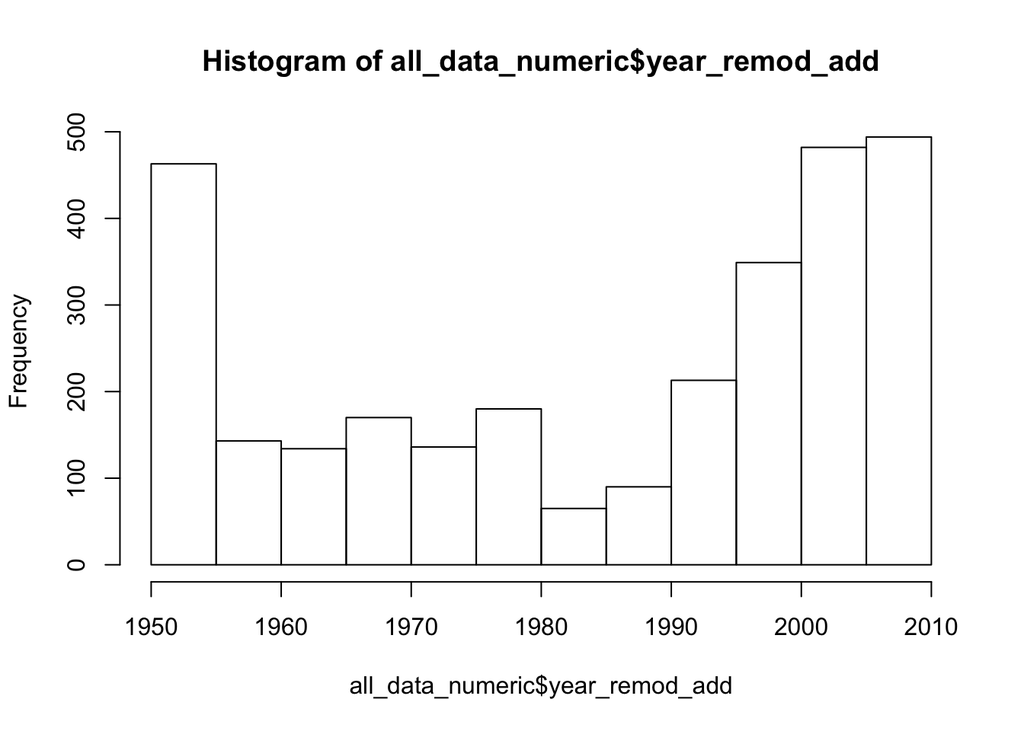

```r
# Histogram of year_remod_add
hist(all_data_numeric$year_remod_add) # Square Transform
```

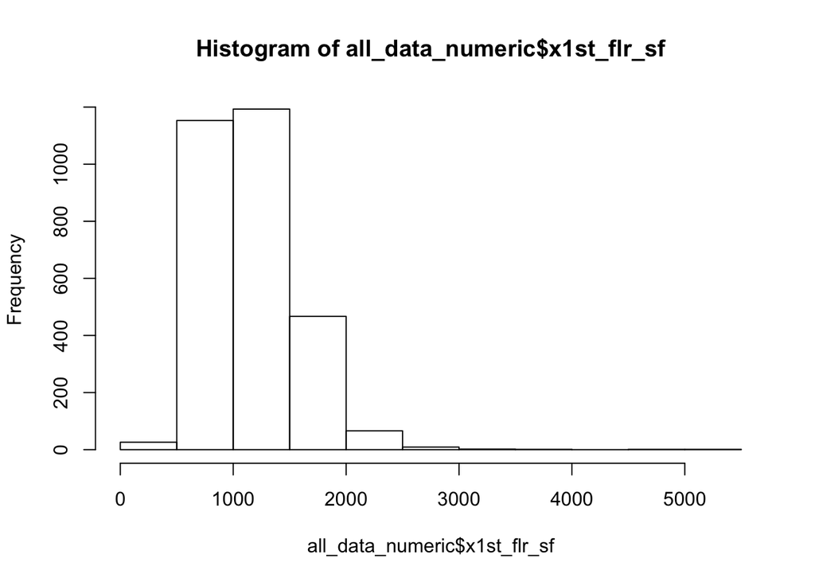

```r
# Histogram of 1st floor surface
hist(all_data_numeric$x1st_flr_sf)    # Log Transform
```

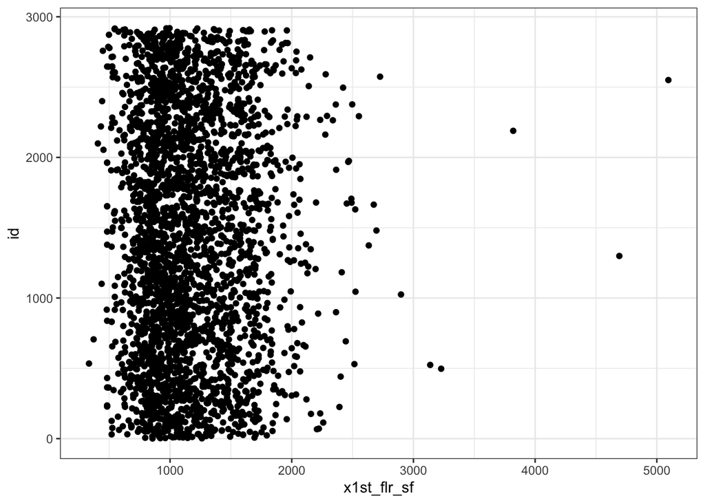

```r
ggplot(data = all_data_numeric) +
  aes(x = x1st_flr_sf, y = id) +
  geom_point()
```

```r
all_data_numeric %>% filter(x1st_flr_sf > 3500)
```

```
## # A tibble: 3 x 37
##      id ms_sub_class lot_frontage lot_area overall_qual overall_cond year_built
##   <dbl>        <dbl>        <dbl>    <dbl>        <dbl>        <dbl>      <dbl>
## 1  1299           60          313    63887           10            5       2008
## 2  2189           20          123    47007            5            7       1959
## 3  2550           20          128    39290           10            5       2008
## # … with 30 more variables: year_remod_add <dbl>, mas_vnr_area <dbl>,
## #   bsmt_fin_sf1 <dbl>, bsmt_fin_sf2 <dbl>, bsmt_unf_sf <dbl>,
## #   total_bsmt_sf <dbl>, x1st_flr_sf <dbl>, x2nd_flr_sf <dbl>,
## #   low_qual_fin_sf <dbl>, gr_liv_area <dbl>, bsmt_full_bath <dbl>,
## #   bsmt_half_bath <dbl>, full_bath <dbl>, half_bath <dbl>,
## #   bedroom_abv_gr <dbl>, kitchen_abv_gr <dbl>, tot_rms_abv_grd <dbl>,
## #   fireplaces <dbl>, garage_yr_blt <dbl>, garage_cars <dbl>,
## #   garage_area <dbl>, wood_deck_sf <dbl>, open_porch_sf <dbl>,
## #   enclosed_porch <dbl>, x3ssn_porch <dbl>, screen_porch <dbl>,
## #   pool_area <dbl>, misc_val <dbl>, mo_sold <dbl>, yr_sold <dbl>
```

```r
# Big houses
all_data_numeric[c(1299,2189,2550),]
```

```
## # A tibble: 3 x 37
##      id ms_sub_class lot_frontage lot_area overall_qual overall_cond year_built
##   <dbl>        <dbl>        <dbl>    <dbl>        <dbl>        <dbl>      <dbl>
## 1  1299           60          313    63887           10            5       2008
## 2  2189           20          123    47007            5            7       1959
## 3  2550           20          128    39290           10            5       2008
## # … with 30 more variables: year_remod_add <dbl>, mas_vnr_area <dbl>,
## #   bsmt_fin_sf1 <dbl>, bsmt_fin_sf2 <dbl>, bsmt_unf_sf <dbl>,
## #   total_bsmt_sf <dbl>, x1st_flr_sf <dbl>, x2nd_flr_sf <dbl>,
## #   low_qual_fin_sf <dbl>, gr_liv_area <dbl>, bsmt_full_bath <dbl>,
## #   bsmt_half_bath <dbl>, full_bath <dbl>, half_bath <dbl>,
## #   bedroom_abv_gr <dbl>, kitchen_abv_gr <dbl>, tot_rms_abv_grd <dbl>,
## #   fireplaces <dbl>, garage_yr_blt <dbl>, garage_cars <dbl>,
## #   garage_area <dbl>, wood_deck_sf <dbl>, open_porch_sf <dbl>,
## #   enclosed_porch <dbl>, x3ssn_porch <dbl>, screen_porch <dbl>,
## #   pool_area <dbl>, misc_val <dbl>, mo_sold <dbl>, yr_sold <dbl>
```

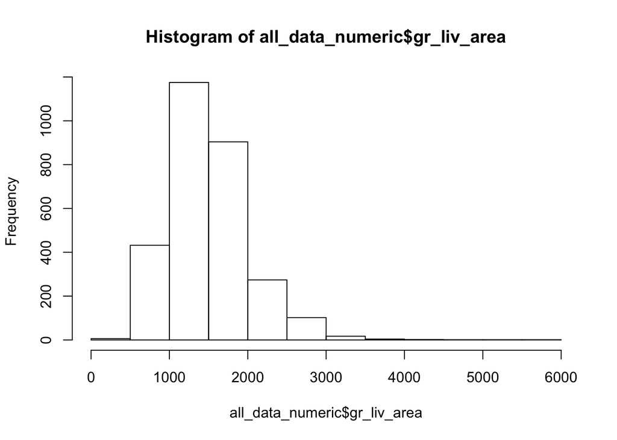

```r
# Histogram of ground living area
hist(all_data_numeric$gr_liv_area)
```

```r
# gr_liv_area = x1st_flr_sf + x2nd_flr_sf + low_qual_fin_sf : redundant in linear model
identical(all_data_numeric$x1st_flr_sf + all_data_numeric$x2nd_flr_sf + all_data_numeric$low_qual_fin_sf, all_data_numeric$gr_liv_area)
```

```
## [1] TRUE
```

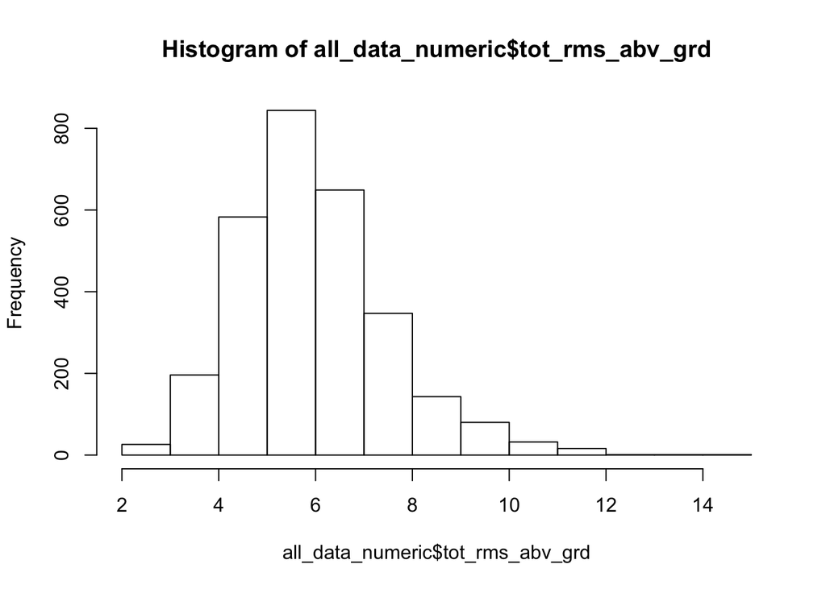

```r
# Histogram of total rooms above ground
hist(all_data_numeric$tot_rms_abv_grd)
```

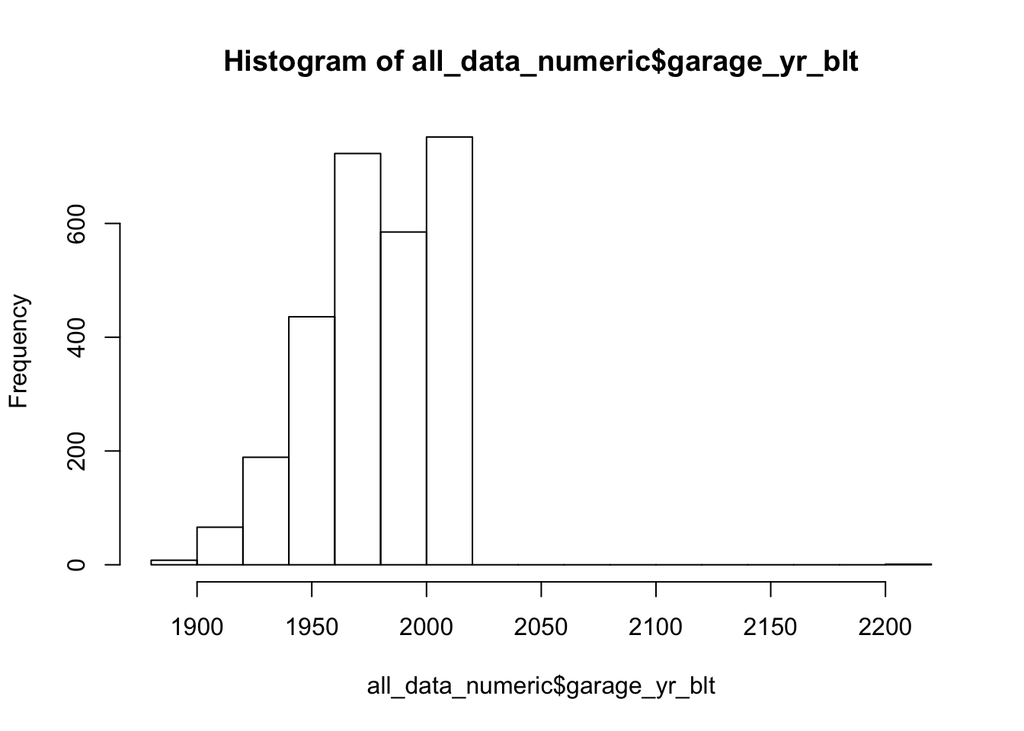

```r
# Histogram of garage_yr_built
hist(all_data_numeric$garage_yr_blt)
```

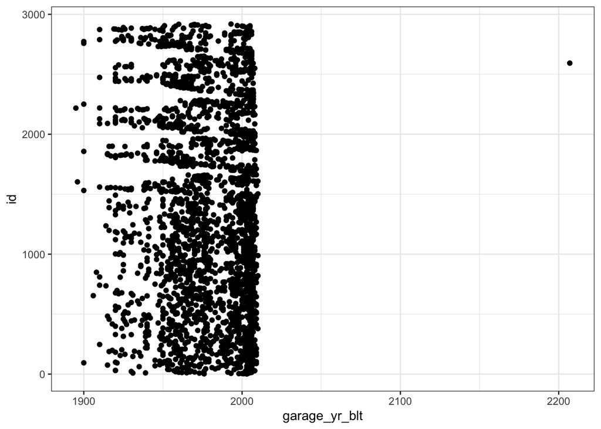

```r
ggplot(data = all_data_numeric) +
  aes(x = garage_yr_blt, y = id) +
  geom_point()
```

```r
all_data_numeric %>%
  filter(garage_yr_blt > 2200) %>%
  select(id, year_built, year_remod_add, garage_yr_blt)
```

```
## # A tibble: 1 x 4
##      id year_built year_remod_add garage_yr_blt
##   <dbl>      <dbl>          <dbl>         <dbl>
## 1  2593       2006           2007          2207
```

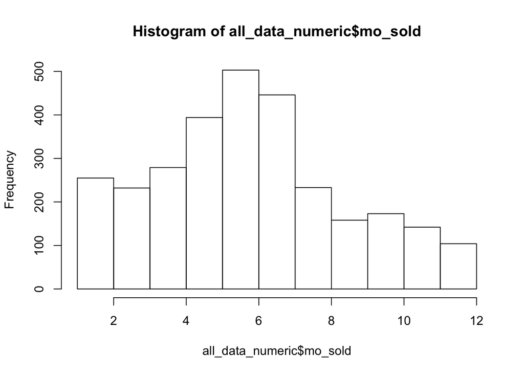

```r
all_data[2593,]$garage_yr_blt <- 2007

# Histogram of mo_sold
hist(all_data_numeric$mo_sold)
```

# Recipe 2 (Transformation for numerical variables)

1. Set Target Variable as sale_price
2. Remove id
3. Log Transformation for sale_price (because it is right-skewed)
4. Impute NAs with mean for all numerical predictors
5. Run BoxCox Transformation for all numerical predictors
6. Normalize all numerical predictors
7. Impute NAs with mode for all nominal predictors
8. Create a Dummy variables for nominal predictors
9. Prep.

```r
# Recipe for the tidymodels
housing_recipe2 <- all_data %>%
    recipe(sale_price ~ .) %>%
    step_rm(id) %>%
    step_log(sale_price) %>%
    step_impute_mean(all_numeric_predictors()) %>%
    step_BoxCox(all_numeric_predictors()) %>%
    step_normalize(all_numeric_predictors()) %>%
    step_impute_mode(all_nominal()) %>%
    step_dummy(all_nominal()) %>%
    prep()

print(housing_recipe2)
```

```
## Data Recipe
##
## Inputs:
##
##       role #variables
##    outcome          1
##  predictor         80
##
## Training data contained 2919 data points and 2919 incomplete rows.
##
## Operations:
##
## Variables removed id [trained]
## Log transformation on sale_price [trained]
## Mean Imputation for ms_sub_class, lot_frontage, ... [trained]
## Box-Cox transformation on ms_sub_class, lot_frontage, ... [trained]
## Centering and scaling for ms_sub_class, lot_frontage, ... [trained]
## Mode Imputation for ms_zoning, street, alley, ... [trained]
## Dummy variables from ms_zoning, street, alley, lot_shape, ... [trained]
```

```r
# Preprocess the recipe1
all_data2 <- recipes::juice(housing_recipe2)
```

```r
# Get the index for trainset
train_index <- seq_len(nrow(train))

# Get the pre-processed trainset
train2 <- all_data2[train_index,]

# Get the pre-processed testset
test2 <- all_data2[-train_index,]
```

```r
# Lasso model using glmnet engine with penalty 0.01 and mixture 1
lasso_model2 <-
  linear_reg(penalty = 0.01, mixture = 1) %>%
  set_engine("glmnet")

# Run the model with formula sale_price ~ .(all other predictors) with dataset train1.
lasso_fit2 <-
  lasso_model2 %>%
  fit(sale_price ~ ., data = train2)

# Find the estimates that are higher than 0.001.
lasso_fit2 %>%
  tidy() %>%
  filter(abs(estimate) > 0.001)
```

```
## # A tibble: 52 x 3
##    term           estimate penalty
##    <chr>             <dbl>   <dbl>
##  1 (Intercept)    11.9        0.01
##  2 lot_area        0.0351     0.01
##  3 overall_qual    0.104      0.01
##  4 overall_cond    0.0349     0.01
##  5 year_built      0.0495     0.01
##  6 year_remod_add  0.0203     0.01
##  7 bsmt_fin_sf1    0.00508    0.01
##  8 total_bsmt_sf   0.00919    0.01
##  9 x1st_flr_sf     0.0258     0.01
## 10 gr_liv_area     0.116      0.01
## # … with 42 more rows
```

```r
# Get the predicted values from the lasso model 1
result2 <- predict(lasso_fit2, test2)
result2 %>% head()
```

```
## # A tibble: 6 x 1
##   .pred
##   <dbl>
## 1  11.7
## 2  12.0
## 3  12.1
## 4  12.2
## 5  12.2
## 6  12.1
```

```r
# Load the submission file
submission <- read_csv(file.path(file_path, "sample_submission.csv"))

# Exponential the sale_price because it is log transformed in preprocessing.
submission$SalePrice <- exp(result2$.pred)

# Write the submission file
write.csv(submission, row.names = FALSE,
          "../output/lasso_regression_0point2.csv")
```

0.13426 (Rank 4117)

# Recipe 3 (Using Median Imputation)

1. Set Target Variable as sale_price
2. Remove id
3. Log Transformation for sale_price (because it is right-skewed)
4. Impute NAs with *Median* for all numerical predictors
5. Run BoxCox Transformation for all numerical predictors
6. Normalize all numerical predictors
7. Impute NAs with mode for all nominal predictors
8. Create a Dummy variables for nominal predictors
9. Prep.

```r
# Recipe for the tidymodels
housing_recipe3 <- all_data %>%
    recipe(sale_price ~ .) %>%
    step_rm(id) %>%
    step_log(sale_price) %>%
    step_impute_median(all_numeric_predictors()) %>%
    step_BoxCox(all_numeric_predictors()) %>%
    step_normalize(all_numeric_predictors()) %>%
    step_impute_mode(all_nominal()) %>%
    step_dummy(all_nominal()) %>%
    prep()

print(housing_recipe3)
```

```
## Data Recipe
##
## Inputs:
##
##       role #variables
##    outcome          1
##  predictor         80
##
## Training data contained 2919 data points and 2919 incomplete rows.
##
## Operations:
##
## Variables removed id [trained]
## Log transformation on sale_price [trained]
## Median Imputation for ms_sub_class, lot_frontage, ... [trained]
## Box-Cox transformation on ms_sub_class, lot_frontage, ... [trained]
## Centering and scaling for ms_sub_class, lot_frontage, ... [trained]
## Mode Imputation for ms_zoning, street, alley, ... [trained]
## Dummy variables from ms_zoning, street, alley, lot_shape, ... [trained]
```

```r
# Preprocess the recipe1
all_data3 <- recipes::juice(housing_recipe3)
```

```r
# Get the index for trainset
train_index <- seq_len(nrow(train))

# Get the pre-processed trainset
train3 <- all_data3[train_index,]

# Get the pre-processed testset
test3 <- all_data3[-train_index,]
```

```r
# Lasso model using glmnet engine with penalty 0.01 and mixture 1
lasso_model3 <-
  linear_reg(penalty = 0.01, mixture = 1) %>%
  set_engine("glmnet")

# Run the model with formula sale_price ~ .(all other predictors) with dataset train1.
lasso_fit3 <-
  lasso_model3 %>%
  fit(sale_price ~ ., data = train3)

# Find the estimates that are higher than 0.001.
lasso_fit3 %>%
  tidy() %>%
  filter(abs(estimate) > 0.001)
```

```
## # A tibble: 52 x 3
##    term           estimate penalty
##    <chr>             <dbl>   <dbl>
##  1 (Intercept)    11.9        0.01
##  2 lot_area        0.0351     0.01
##  3 overall_qual    0.104      0.01
##  4 overall_cond    0.0349     0.01
##  5 year_built      0.0495     0.01
##  6 year_remod_add  0.0203     0.01
##  7 bsmt_fin_sf1    0.00508    0.01
##  8 total_bsmt_sf   0.00919    0.01
##  9 x1st_flr_sf     0.0258     0.01
## 10 gr_liv_area     0.116      0.01
## # … with 42 more rows
```

```r
# Get the predicted values from the lasso model 1
result3 <- predict(lasso_fit3, test3)
result3 %>% head()
```

```
## # A tibble: 6 x 1
##   .pred
##   <dbl>
## 1  11.7
## 2  12.0
## 3  12.1
## 4  12.2
## 5  12.2
## 6  12.1
```

```r
# Load the submission file
submission <- read_csv(file.path(file_path, "sample_submission.csv"))

# Exponential the sale_price because it is log transformed in preprocessing.
submission$SalePrice <- exp(result3$.pred)

# Write the submission file
write.csv(submission, row.names = FALSE,
          "../output/lasso_regression_0point3.csv")
```

0.13435 (Recipe 2 is better)

# Recipe 4 ( ms_sub_class into categorical variable)

1. Set Target Variable as sale_price
2. Remove id
3. Log Transformation for sale_price (because it is right-skewed)
4. Impute NAs with mean for all numerical predictors
5. Run BoxCox Transformation for all numerical predictors
6. Normalize all numerical predictors
7. Impute NAs with mode for all nominal predictors
8. Create a Dummy variables for nominal predictors
9. Prep.

```r
# Remove NA dominant variables (pool_qc, fence, misc_feature, alley, id)
all <- all_data %>%
  select(-c(pool_qc, fence, misc_feature, alley, id)) %>%
  mutate_if(is.character, as.factor) %>% # Character -> Factor
  mutate(
    ms_sub_class = as.factor(ms_sub_class), # MSSubClass는 범주형 변수이므로 factor로 변환
    overall_qual = factor(overall_qual, order = T, levels = c(1,2,3,4,5,6,7,8,9,10)),
    overall_cond = factor(overall_cond, order = T, levels = c(1,2,3,4,5,6,7,8,9,10)))
```

```r
# Recipe for the tidymodels
housing_recipe4 <- all %>%
    recipe(sale_price ~ .) %>%
    step_log(sale_price) %>%
    step_impute_mean(all_numeric_predictors()) %>%
    step_BoxCox(all_numeric_predictors()) %>%
    step_impute_mode(all_nominal()) %>%
    step_dummy(all_nominal()) %>%
    step_normalize(all_predictors()) %>%
    prep()

print(housing_recipe4)
```

```
## Data Recipe
##
## Inputs:
##
##       role #variables
##    outcome          1
##  predictor         75
##
## Training data contained 2919 data points and 2336 incomplete rows.
##
## Operations:
##
## Log transformation on sale_price [trained]
## Mean Imputation for lot_frontage, lot_area, ... [trained]
## Box-Cox transformation on lot_frontage, lot_area, ... [trained]
## Mode Imputation for ms_sub_class, ms_zoning, street, ... [trained]
## Dummy variables from ms_sub_class, ms_zoning, street, lot_shape, ... [trained]
## Centering and scaling for lot_frontage, lot_area, ... [trained]
```

```r
# Preprocess the recipe4
all_data4 <- recipes::juice(housing_recipe4)
```

```r
# Get the index for trainset
train_index <- seq_len(nrow(train))

# Get the pre-processed trainset
train4 <- all_data4[train_index,]

# Get the pre-processed testset
test4 <- all_data4[-train_index,]
```

```r
# Lasso model using glmnet engine with penalty 0.01 and mixture 1
lasso_model4 <-
  linear_reg(penalty = 0.01, mixture = 1) %>%
  set_engine("glmnet")

# Run the model with formula sale_price ~ .(all other predictors) with dataset train1.
lasso_fit4 <-
  lasso_model4 %>%
  fit(sale_price ~ ., data = train4)

# Find the estimates that are higher than 0.001.
lasso_fit4 %>%
  tidy() %>%
  filter(abs(estimate) > 0.001)
```

```
## # A tibble: 46 x 3
##    term           estimate penalty
##    <chr>             <dbl>   <dbl>
##  1 (Intercept)    12.0        0.01
##  2 lot_area        0.0343     0.01
##  3 year_built      0.0508     0.01
##  4 year_remod_add  0.0202     0.01
##  5 bsmt_fin_sf1    0.00186    0.01
##  6 total_bsmt_sf   0.00671    0.01
##  7 x1st_flr_sf     0.0263     0.01
##  8 gr_liv_area     0.117      0.01
##  9 bsmt_full_bath  0.0145     0.01
## 10 kitchen_abv_gr -0.00848    0.01
## # … with 36 more rows
```

```r
# Get the predicted values from the lasso model 4
result4 <- predict(lasso_fit4, test4)
result4 %>% head()
```

```
## # A tibble: 6 x 1
##   .pred
##   <dbl>
## 1  11.6
## 2  11.9
## 3  12.1
## 4  12.2
## 5  12.2
## 6  12.1
```

```r
# Load the submission file
submission <- read_csv(file.path(file_path, "sample_submission.csv"))

# Exponential the sale_price because it is log transformed in preprocessing.
submission$SalePrice <- exp(result4$.pred)

# Write the submission file
write.csv(submission, row.names = FALSE,
          "../output/lasso_regression_0point4.csv")
```

0.13435